# Budweiser Case Study

Ravi Sivaraman

7/4/2020

## Craft Beers and Breweries

An analysis of 2410 US craft beers and 558 breweries across United States. Budweiser CFO presented dataset of 2410 US craft beers and 558 breweries to us to analyze and find interesting data report that may be intersting prospect for Budweiser. We did an analysis of the beers and breweries dataset, and found lot of useful information that is benefitial to Budweiser.

## Import Data

The section imports the data into R

```r
breweries <- read.csv("Breweries.csv")
beers <- read.csv("Beers.csv")
```

## 1 Breweries by State

```r
#-------------------------------------------------------------------------
#The following section of the code loads the breweries and selects only
#the State column.
#group by, groups the breweries by state
#summarize, adds the count of breweries by state
#brewbystate contains a dataframe that has State and number of breweries in that state
#-------------------------------------------------------------------------

brewbystate <- breweries %>% select(State) %>% group_by(State) %>% summarize(Count=n())
brewbystate <- brewbystate[order(brewbystate$Count, decreasing = TRUE),]
brewbystate$State = factor(brewbystate$State, levels = brewbystate$State[order(brewbystate$Count, decreasing = TRUE)])
```

The following list containst the list of breweries in United States by State.

```r
#This is to generate the table
kable(brewbystate) %>%
  kable_styling(bootstrap_options = c("striped", "hover", "responsive"), full_width = F, position="left")
```

| State | Count |
| --- | --- |
| CO | 47 |
| CA | 39 |
| MI | 32 |
| OR | 29 |
| TX | 28 |
| PA | 25 |
| MA | 23 |
| WA | 23 |
| IN | 22 |
| WI | 20 |
| NC | 19 |
| IL | 18 |
| NY | 16 |
| VA | 16 |
| FL | 15 |
| OH | 15 |
| MN | 12 |
| AZ | 11 |
| VT | 10 |
| ME | 9 |
| MO | 9 |
| MT | 9 |
| CT | 8 |
| AK | 7 |
| GA | 7 |
| MD | 7 |
| OK | 6 |
| IA | 5 |
| ID | 5 |
| LA | 5 |
| NE | 5 |
| RI | 5 |
| HI | 4 |
| KY | 4 |
| NM | 4 |
| SC | 4 |
| UT | 4 |
| WY | 4 |
| AL | 3 |
| KS | 3 |
| NH | 3 |
| NJ | 3 |
| TN | 3 |
| AR | 2 |
| DE | 2 |
| MS | 2 |
| NV | 2 |
| DC | 1 |
| ND | 1 |
| SD | 1 |
| WV | 1 |

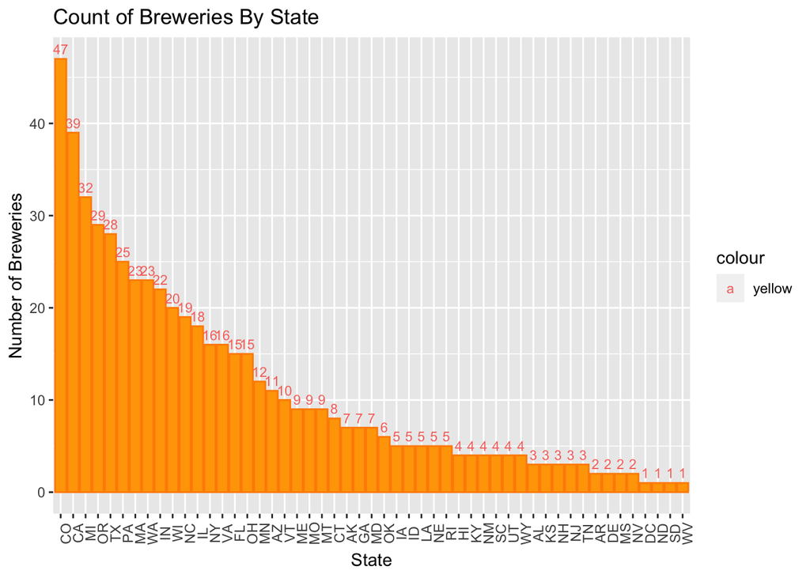

```r
#This is to plot
brewbystate %>%ggplot(aes(x=State,y=Count)) + geom_col(color="darkorange", fill="orange") + xlab("State") + ylab("Number of Breweries") + ggtitle("Count of Breweries By State") + theme(axis.text.x = element_text(angle = 90)) + geom_text(aes(label=Count, color="yellow"), vjust=-.5, size=3)
```

## 2 Merge Breweries and Brews data

```r
colnames(breweries)[1] = "Brewery_id"
brewandbeers = merge(breweries, beers, by ="Brewery_id")
colnames(brewandbeers)[1] = "ID"
colnames(brewandbeers)[2] = "Brewery"
colnames(brewandbeers)[5] = "Beer"
kable(brewandbeers[1:6,]) %>%
  kable_styling(bootstrap_options = c("striped", "hover", "responsive"), full_width = F, position="left")
```

| ID | Brewery | City | State | Beer | Beer_ID | ABV | IBU | Style | Ounces |
| --- | --- | --- | --- | --- | --- | --- | --- | --- | --- |
| 1 | NorthGate Brewing | Minneapolis | MN | Pumpion | 2689 | 0.060 | 38 | Pumpkin Ale | 16 |
| 1 | NorthGate Brewing | Minneapolis | MN | Stronghold | 2688 | 0.060 | 25 | American Porter | 16 |
| 1 | NorthGate Brewing | Minneapolis | MN | Parapet ESB | 2687 | 0.056 | 47 | Extra Special / Strong Bitter (ESB) | 16 |
| 1 | NorthGate Brewing | Minneapolis | MN | Get Together | 2692 | 0.045 | 50 | American IPA | 16 |
| 1 | NorthGate Brewing | Minneapolis | MN | Maggie’s Leap | 2691 | 0.049 | 26 | Milk / Sweet Stout | 16 |
| 1 | NorthGate Brewing | Minneapolis | MN | Wall’s End | 2690 | 0.048 | 19 | English Brown Ale | 16 |

```r
kable(tail(brewandbeers, keepnums = FALSE)) %>%
  kable_styling(bootstrap_options = c("striped", "hover", "responsive"), full_width = F, position="left")
```

|  | ID | Brewery | City | State | Beer | Beer_ID | ABV | IBU | Style | Ounces |
| --- | --- | --- | --- | --- | --- | --- | --- | --- | --- | --- |
| 2405 | 556 | Ukiah Brewing Company | Ukiah | CA | Pilsner Ukiah | 98 | 0.055 | NA | German Pilsener | 12 |
| 2406 | 557 | Butternuts Beer and Ale | Garrattsville | NY | Porkslap Pale Ale | 49 | 0.043 | NA | American Pale Ale (APA) | 12 |
| 2407 | 557 | Butternuts Beer and Ale | Garrattsville | NY | Snapperhead IPA | 51 | 0.068 | NA | American IPA | 12 |
| 2408 | 557 | Butternuts Beer and Ale | Garrattsville | NY | Moo Thunder Stout | 50 | 0.049 | NA | Milk / Sweet Stout | 12 |
| 2409 | 557 | Butternuts Beer and Ale | Garrattsville | NY | Heinnieweisse Weissebier | 52 | 0.049 | NA | Hefeweizen | 12 |
| 2410 | 558 | Sleeping Lady Brewing Company | Anchorage | AK | Urban Wilderness Pale Ale | 30 | 0.049 | NA | English Pale Ale | 12 |

## 3 Missing Values

```r
#Replace NA with minimum value of ABV and IBU respectively.
minABV = min(brewandbeers$ABV, na.rm = TRUE)
brewandbeers <- brewandbeers %>% mutate(ABV=replace_na(ABV,minABV))

minIBU = min(brewandbeers$IBU, na.rm = TRUE)
brewandbeers <- brewandbeers %>% mutate(IBU=replace_na(IBU,minIBU))
```

## 4 Median ABV and IBU by State

The following list shows the median IBU and ABV by State

```r
# Computes the median ABV and median IBU
#Groups by State
medianstate<- brewandbeers %>% group_by(State) %>% summarize("Median ABV"=median(ABV), "Median IBU"=median(IBU))
kable(medianstate) %>%
  kable_styling(bootstrap_options = c("striped", "hover", "responsive"), full_width = F, position="left")
```

| State | Median ABV | Median IBU |
| --- | --- | --- |
| AK | 0.0560 | 17.0 |
| AL | 0.0600 | 39.5 |
| AR | 0.0520 | 4.0 |
| AZ | 0.0550 | 9.0 |
| CA | 0.0580 | 28.0 |
| CO | 0.0590 | 17.0 |
| CT | 0.0600 | 4.0 |
| DC | 0.0625 | 7.5 |
| DE | 0.0280 | 28.0 |
| FL | 0.0555 | 25.0 |
| GA | 0.0550 | 4.0 |
| HI | 0.0540 | 18.0 |
| IA | 0.0555 | 24.5 |
| ID | 0.0565 | 12.0 |
| IL | 0.0580 | 4.0 |
| IN | 0.0580 | 23.0 |
| KS | 0.0500 | 20.0 |
| KY | 0.0600 | 20.0 |
| LA | 0.0520 | 13.0 |
| MA | 0.0540 | 16.5 |
| MD | 0.0580 | 4.0 |
| ME | 0.0510 | 4.0 |
| MI | 0.0600 | 4.0 |
| MN | 0.0560 | 38.0 |
| MO | 0.0515 | 18.0 |
| MS | 0.0580 | 45.0 |
| MT | 0.0545 | 15.0 |
| NC | 0.0570 | 5.0 |
| ND | 0.0500 | 32.0 |
| NE | 0.0520 | 4.0 |
| NH | 0.0550 | 4.0 |
| NJ | 0.0460 | 34.5 |
| NM | 0.0610 | 4.0 |
| NV | 0.0580 | 35.0 |
| NY | 0.0550 | 22.5 |
| OH | 0.0580 | 21.0 |
| OK | 0.0600 | 10.0 |
| OR | 0.0560 | 22.0 |
| PA | 0.0560 | 4.0 |
| RI | 0.0550 | 22.0 |
| SC | 0.0550 | 4.0 |
| SD | 0.0600 | 4.0 |
| TN | 0.0570 | 34.5 |
| TX | 0.0550 | 21.0 |
| UT | 0.0400 | 4.0 |
| VA | 0.0565 | 37.5 |
| VT | 0.0550 | 20.0 |
| WA | 0.0555 | 29.5 |
| WI | 0.0520 | 4.0 |
| WV | 0.0620 | 57.5 |
| WY | 0.0500 | 20.0 |

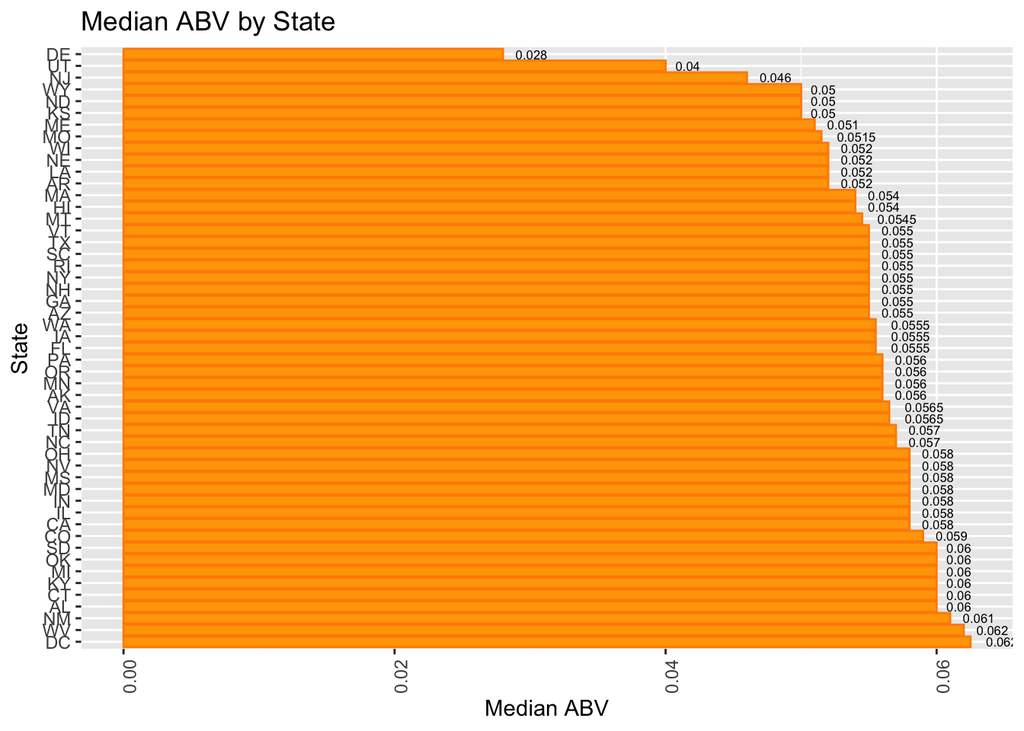

```r
#Plot the bar graph
colnames(medianstate)[2] ="MedianABV"
medianstateABV <- medianstate[order(medianstate$MedianABV, decreasing = TRUE),]
medianstateABV$State <- factor(medianstateABV$State, levels = medianstateABV$State[order(medianstateABV$MedianABV, decreasing = TRUE)])


medianstateABV %>%ggplot(aes(x=State,y=MedianABV)) + geom_col(color="darkorange", fill="orange") + xlab("State") + ylab("Median ABV") + ggtitle("Median ABV by State") + theme(axis.text.x = element_text(angle = 90)) + geom_text(aes(label=MedianABV), hjust=-.4, size=2.2) +   coord_flip()
```

[figure not shown]

```r
colnames(medianstate)[2] ="MedianIBU"
medianstateIBU <- medianstate[order(medianstate$MedianIBU, decreasing = TRUE),]
medianstateIBU$State <- factor(medianstateIBU$State, levels = medianstateIBU$State[order(medianstateIBU$MedianIBU, decreasing = TRUE)])


medianstateIBU %>%ggplot(aes(x=State,y=MedianIBU)) + geom_col(color="darkorange", fill="orange") + xlab("State") + ylab("Median IBU") + ggtitle("Median IBU by State") + theme(axis.text.x = element_text(angle = 90)) + geom_text(aes(label=MedianIBU), hjust=-.4, size=2.2) +   coord_flip()
```